# influ2

Darcy Webber

# Introduction

The `influ2` package is based on the original `influ` package which was developed to generate influence statistics and associated plots. The `influ` package has functions that use outputs from the `glm` function. The `influ2` package was developed to use outputs from `brms` and relies heavily on the R packages `ggplot2` and `dplyr`. This vignette showcases the `influ2` package.

# Functions for exploring data

In this vignette I use the `iris` data set to generate a fake catch per unit effort (CPUE) data set. This data set has a response variable labelled `CPUE` and has the dependent variables `Year` (from 1990 to 2014), `Species` (3 species), `Area` (3 areas) and `Duration`. No step-wise variable selection or model selection is done in this vignette.

The main function for exploring data in `influ2` is `plot_bubble` which presents the number of records by two user defined groups within a data set. The bubble size in `plot_bubble` represents the number of records across the entire data set, and bubbles can either be a single colour or coloured by a third variable in the data set.

```r
library(reshape2)
library(tidyverse)
library(brms)
library(influ2)
library(bayesplot)

# options(mc.cores = parallel::detectCores())

# Get some data to use
data(iris)
glimpse(iris)
```

```
#> Rows: 150
#> Columns: 5
#> $ Sepal.Length <dbl> 5.1, 4.9, 4.7, 4.6, 5.0, 5.4, 4.6, 5.0, 4.4, 4.9, 5.4, 4…
#> $ Sepal.Width  <dbl> 3.5, 3.0, 3.2, 3.1, 3.6, 3.9, 3.4, 3.4, 2.9, 3.1, 3.7, 3…
#> $ Petal.Length <dbl> 1.4, 1.4, 1.3, 1.5, 1.4, 1.7, 1.4, 1.5, 1.4, 1.5, 1.5, 1…
#> $ Petal.Width  <dbl> 0.2, 0.2, 0.2, 0.2, 0.2, 0.4, 0.3, 0.2, 0.2, 0.1, 0.2, 0…
#> $ Species      <fct> setosa, setosa, setosa, setosa, setosa, setosa, setosa, …
```

```r
iris2 <- iris %>%
  mutate(CPUE = Petal.Length,
         Year = factor(Sepal.Width * 10 + 1970),
         Area = factor(round(Petal.Width)),
         Duration = Sepal.Length,
         Duration2 = cut(Sepal.Length, 20)) %>%
  select(CPUE, Year, Species, Area, Duration, Duration2)
glimpse(iris2)
```

```
#> Rows: 150
#> Columns: 6
#> $ CPUE      <dbl> 1.4, 1.4, 1.3, 1.5, 1.4, 1.7, 1.4, 1.5, 1.4, 1.5, 1.5, 1.6,…
#> $ Year      <fct> 2005, 2000, 2002, 2001, 2006, 2009, 2004, 2004, 1999, 2001,…
#> $ Species   <fct> setosa, setosa, setosa, setosa, setosa, setosa, setosa, set…
#> $ Area      <fct> 0, 0, 0, 0, 0, 0, 0, 0, 0, 0, 0, 0, 0, 0, 0, 0, 0, 0, 0, 0,…
#> $ Duration  <dbl> 5.1, 4.9, 4.7, 4.6, 5.0, 5.4, 4.6, 5.0, 4.4, 4.9, 5.4, 4.8,…
#> $ Duration2 <fct> "(5.02,5.2]", "(4.84,5.02]", "(4.66,4.84]", "(4.48,4.66]", …
```

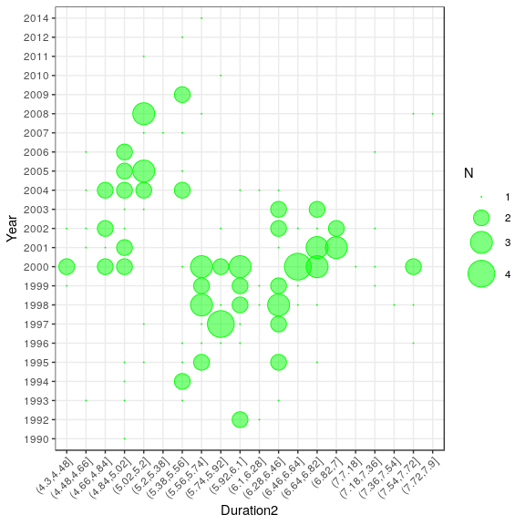

Distribution of data by year and duration.

```r
plot_bubble(df = iris2, group = c("Year", "Duration2"), fill = "green")
```

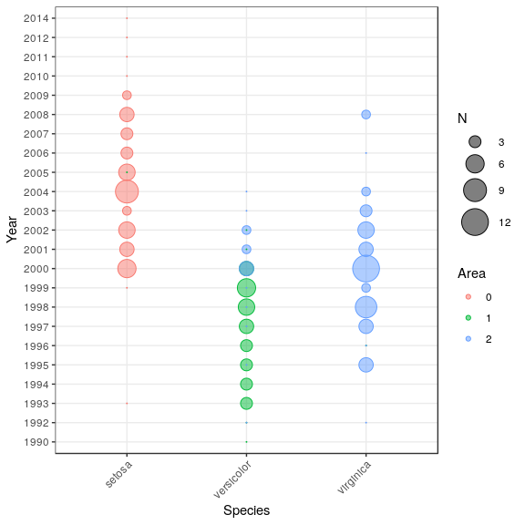

Distribution of data by year and species.

```r
plot_bubble(df = iris2, group = c("Year", "Species"), fill = "Area")
```

# The origninal influ versus influ2

```r
# Fit a series of models using brms
do_mcmc <- FALSE
if (do_mcmc) {
  # A set of lognormal models
  fit0 <- brm(CPUE ~ Year, data = iris2, family = lognormal(), refresh = 0)
  fit1 <- brm(CPUE ~ Year + Duration, data = iris2, family = lognormal(), refresh = 0)
  fit2 <- brm(CPUE ~ Year + Duration + Species, data = iris2, family = lognormal(), refresh = 0)

  # Gaussian, Gamma, and Weibull
  fit3 <- brm(CPUE ~ Year + poly(Duration, 3), data = iris2, refresh = 0)
  fit4 <- brm(CPUE ~ Year + s(Duration), data = iris2, family = Gamma(link = "log"), refresh = 0)
  fit5 <- brm(CPUE ~ Year + (1|Duration2), data = iris2, family = weibull, refresh = 0)

  save(fit0, fit1, fit2, fit3, fit4, fit5, file = "mcmc.rda")
} else{
  load("mcmc.rda")
}

# Fit a model using glm and generate influence statistics using the original influ package
fit_glm <- glm(log(CPUE) ~ Year + Duration + Species, data = iris2)
source("../tests/testthat/influ.R")
myInfl <- Influence$new(fit_glm)
myInfl$calc()
```

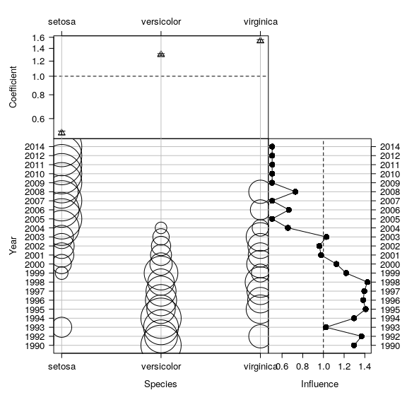

The original CDI plot from the influ package.

```r
myInfl$cdiPlot(term = "Species")
```

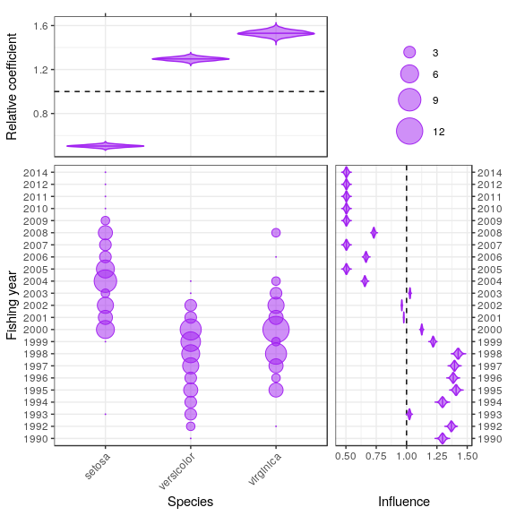

A Bayesian version of original CDI plot.

```r
# Generate a CDI plot for a factor - this version aims to look the same as the old version
plot_bayesian_cdi2(fit = fit2, group = c("Year", "Species"), xlab = "Species")
```

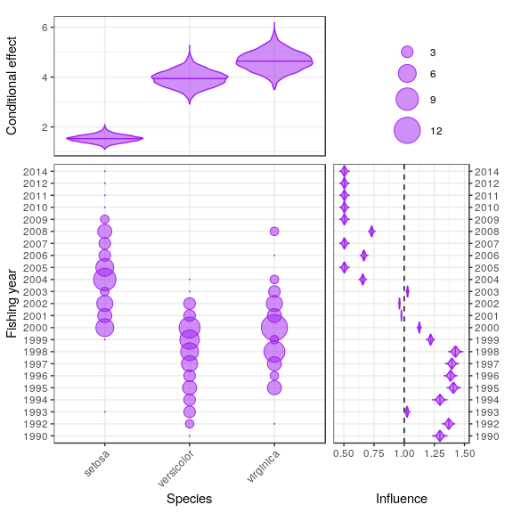

The new Bayesian CDI plot from the influ2 package.

```r
# Generate a CDI plot for a factor
plot_bayesian_cdi(fit = fit2, group = c("Year", "Species"), xlab = "Species")
```

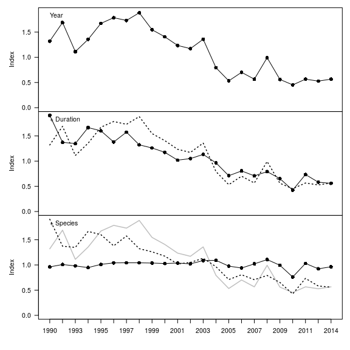

The original step-plot from the influ package.

```r
myInfl$stepPlot()
```

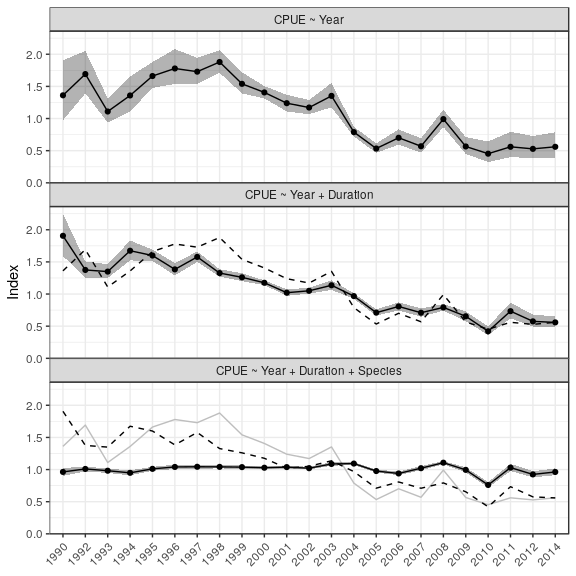

The new Bayesian step-plot from the influ2 package. Note that the new step-plot requires that all models/steps be run in brms before the function can be used.

```r
fits <- list(fit0, fit1, fit2)
plot_step(fits = fits, year = "Year", probs = c(0.25, 0.75), show_probs = TRUE)
```

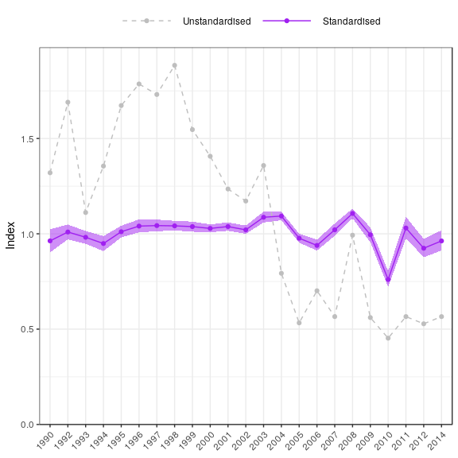

```r
plot_index(fit2, year = "Year")
```

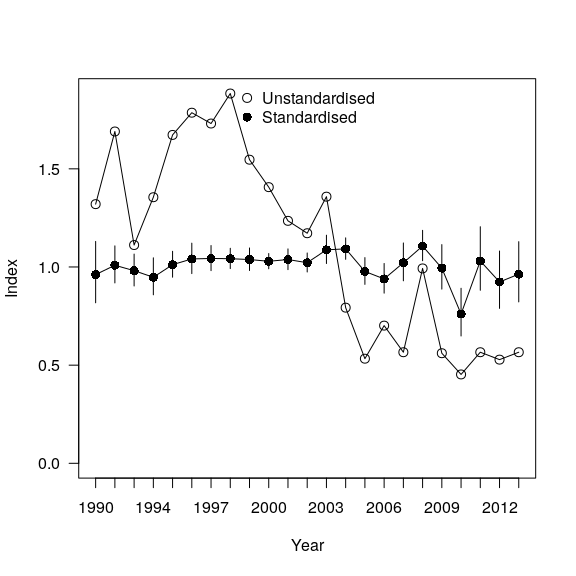

```r
myInfl$stanPlot()
```

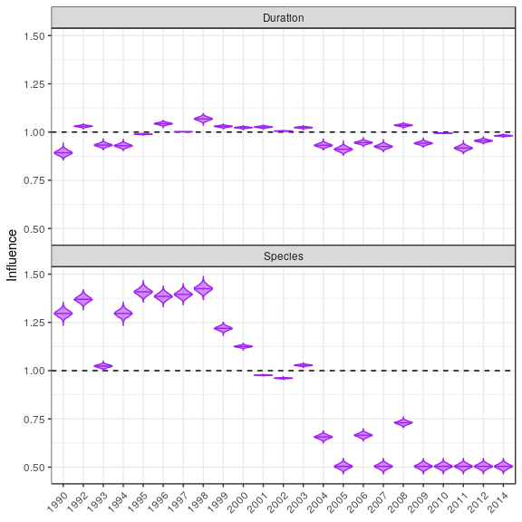

```r
plot_influ(fit2, year = "Year")
```

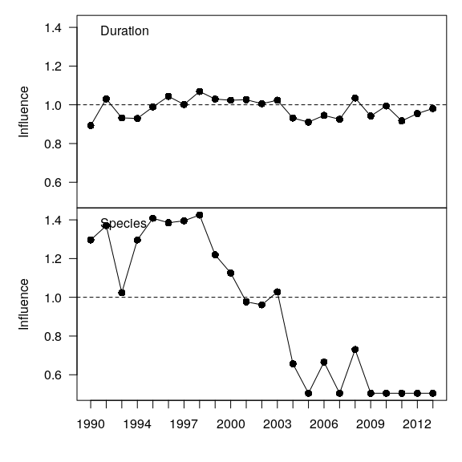

```r
myInfl$influPlot()
```

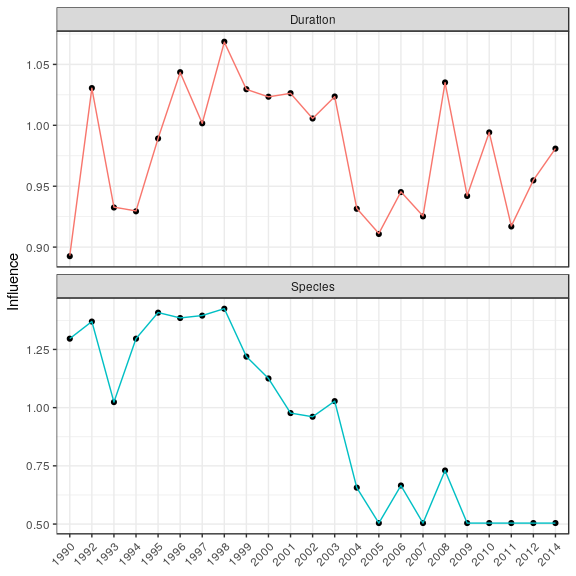

```r
i1 <- myInfl$influences %>%
  pivot_longer(cols = -level, names_to = "variable")
i2 <- get_influ(fit = fit2, group = c("Year", "Species")) %>%
  group_by(Year) %>%
  summarise(delta = mean(delta)) %>%
  mutate(variable = "Species")
i3 <- get_influ(fit = fit2, group = c("Year", "Duration")) %>%
  group_by(Year) %>%
  summarise(delta = mean(delta)) %>%
  mutate(variable = "Duration")

ggplot(data = rbind(i2, i3)) +
  geom_point(data = i1, aes(x = level, y = exp(value))) +
  geom_line(aes(x = Year, y = exp(delta), colour = variable, group = variable)) +
  facet_wrap(variable ~ ., ncol = 1, scales = "free_y") +
  labs(x = NULL, y = "Influence") +
  theme_bw() +
  theme(legend.position = "none", axis.text.x = element_text(angle = 45, hjust = 1))
```

# Functions for exploring models

```r
# Here I evaluate model fit using loo and waic.
# Other options include kfold, loo_subsample, bayes_R2, loo_R2 and marglik
fit0 <- add_criterion(fit0, criterion = c("loo", "waic"))
fit1 <- add_criterion(fit1, criterion = c("loo", "waic"))
fit2 <- add_criterion(fit2, criterion = c("loo", "waic"))
fit3 <- add_criterion(fit3, criterion = c("loo", "waic"))
fit4 <- add_criterion(fit4, criterion = c("loo", "waic"))
fit5 <- add_criterion(fit5, criterion = c("loo", "waic"))
fit0$criteria$loo
```

```
#>
#> Computed from 4000 by 150 log-likelihood matrix
#>
#>          Estimate   SE
#> elpd_loo   -297.5  9.2
#> p_loo        20.1  2.7
#> looic       595.1 18.4
#> ------
#> Monte Carlo SE of elpd_loo is NA.
#>
#> Pareto k diagnostic values:
#>                          Count Pct.    Min. n_eff
#> (-Inf, 0.5]   (good)     143   95.3%   294
#>  (0.5, 0.7]   (ok)         2    1.3%   698
#>    (0.7, 1]   (bad)        3    2.0%   35
#>    (1, Inf)   (very bad)   2    1.3%   6
#> See help('pareto-k-diagnostic') for details.
```

```r
fit0$criteria$waic
```

```
#>
#> Computed from 4000 by 150 log-likelihood matrix
#>
#>           Estimate   SE
#> elpd_waic   -295.5  9.2
#> p_waic        18.1  2.3
#> waic         590.9 18.4
#>
#> 13 (8.7%) p_waic estimates greater than 0.4. We recommend trying loo instead.
```

```r
loo_compare(fit0, fit1, fit2, fit3, fit4, fit5, criterion = "loo") %>%
  knitr::kable(digits = 1)
```

|  | elpd_diff | se_diff | elpd_loo | se_elpd_loo | p_loo | se_p_loo | looic | se_looic |
| --- | --- | --- | --- | --- | --- | --- | --- | --- |
| fit2 | 0.0 | 0.0 | -29.1 | 11.5 | 28.1 | 4.4 | 58.2 | 23.0 |
| fit3 | -124.5 | 13.9 | -153.6 | 8.1 | 23.8 | 2.7 | 307.1 | 16.3 |
| fit4 | -133.6 | 14.7 | -162.7 | 12.3 | 29.0 | 4.2 | 325.4 | 24.5 |
| fit1 | -154.3 | 13.0 | -183.4 | 10.3 | 20.5 | 2.4 | 366.8 | 20.6 |
| fit5 | -157.1 | 14.6 | -186.2 | 11.1 | 42.9 | 6.2 | 372.5 | 22.3 |
| fit0 | -268.4 | 13.4 | -297.5 | 9.2 | 20.1 | 2.7 | 595.1 | 18.4 |

```r
loo_compare(fit0, fit1, fit2, fit3, fit4, fit5, criterion = "waic") %>%
  knitr::kable(digits = 1)
```

|  | elpd_diff | se_diff | elpd_waic | se_elpd_waic | p_waic | se_p_waic | waic | se_waic |
| --- | --- | --- | --- | --- | --- | --- | --- | --- |
| fit2 | 0.0 | 0.0 | -26.4 | 11.4 | 25.4 | 3.9 | 52.8 | 22.7 |
| fit3 | -124.8 | 13.7 | -151.2 | 8.0 | 21.4 | 2.3 | 302.3 | 16.0 |
| fit4 | -133.9 | 14.6 | -160.3 | 12.3 | 26.5 | 4.0 | 320.5 | 24.5 |
| fit5 | -152.3 | 13.6 | -178.7 | 10.0 | 35.4 | 4.4 | 357.5 | 19.9 |
| fit1 | -155.0 | 12.8 | -181.4 | 10.3 | 18.5 | 1.9 | 362.7 | 20.6 |
| fit0 | -269.1 | 13.2 | -295.5 | 9.2 | 18.1 | 2.3 | 590.9 | 18.4 |

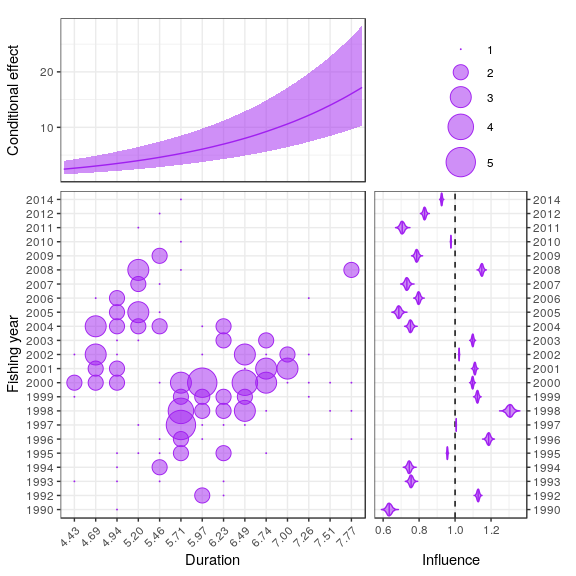

```r
# Generate a CDI plot for a linear variable
plot_bayesian_cdi(fit = fit1, group = c("Year", "Duration"), xlab = "Duration")
```

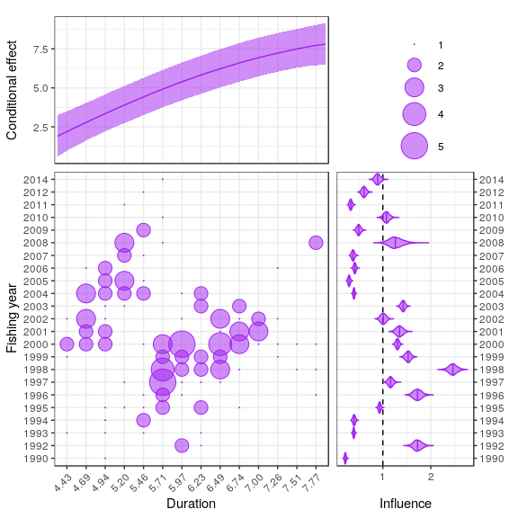

```r
# Generate a CDI plot for a polynomial variable
plot_bayesian_cdi(fit = fit3, group = c("Year", "Duration"), xlab = "Duration")
```

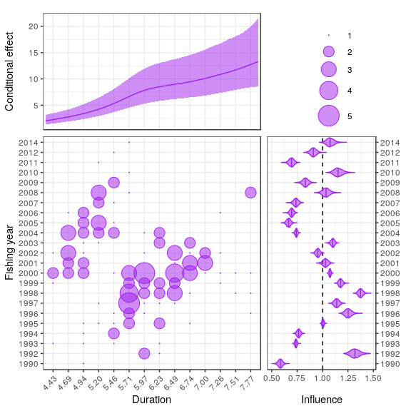

```r
# Generate a CDI plot for a spline
plot_bayesian_cdi(fit = fit4, group = c("Year", "Duration"), xlab = "Duration")
```

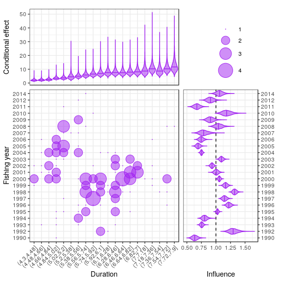

```r
# Generate a CDI plot for a random-effect
plot_bayesian_cdi(fit = fit5, group = c("Year", "Duration2"), xlab = "Duration")
```

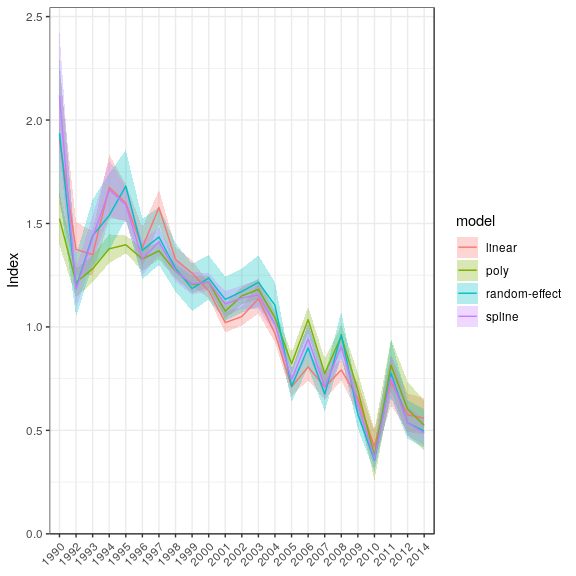

```r
fits <- list(fit1, fit3, fit4, fit5)
plot_compare(fits = fits, labels = c("linear", "poly", "spline", "random-effect"), year = "Year")
```

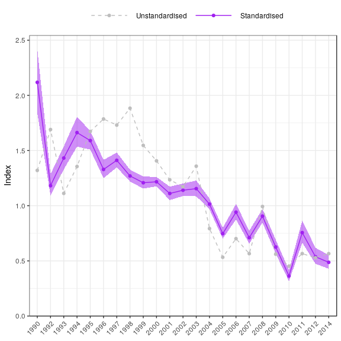

```r
plot_index(fit = fit4, year = "Year")
```

# Diagnostics

The `influ2` package is based on the original `influ` package which was developed to generate influence plots. The `influ` package has functions that use outputs from the `glm` function. The `influ2` package was developed to use outputs from `brms` and relies heavily on the R packages `ggplot2` and `dplyr`. This vignette showcases the `influ2` package with a focus on model diagnostics including posterior predictive distributions, residuals, and quantile-quantile plots.

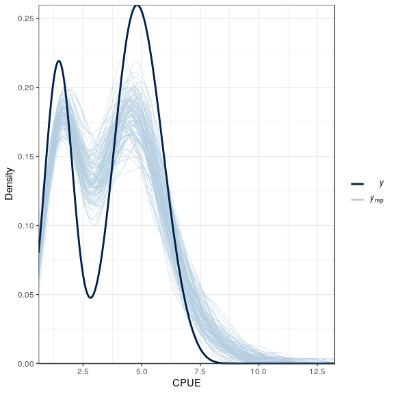

```r
yrep <- posterior_predict(fit4, draws = 500)
ppc_dens_overlay(y = iris2$CPUE, yrep = yrep[1:100,]) +
  labs(x = "CPUE", y = "Density") +
  theme_bw()
```

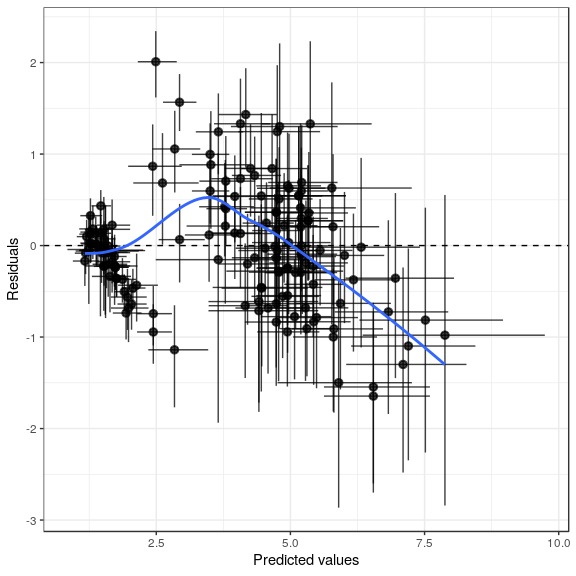

```r
plot_predicted_residuals(fit4)
```

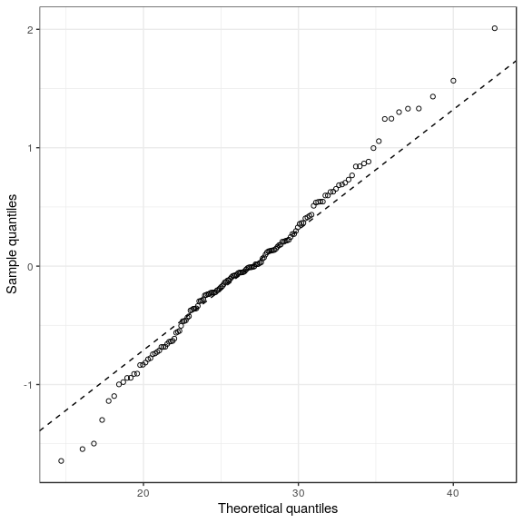

```r
plot_qq(fit4)
```

# Functions for generating outputs for stock assessment

Finally, in order to fit to the data in a stock assessment model then indices can be produced using the `get_index` function.

```r
get_index(fit = fit2, year = "Year") %>%
  select(Year, Estimate, Est.Error, Qlower, Q50, Qupper) %>%
  knitr::kable(digits = 3)
```

| Year | Estimate | Est.Error | Qlower | Q50 | Qupper |
| --- | --- | --- | --- | --- | --- |
| 1990 | 0.962 | 0.090 | 0.795 | 0.963 | 1.150 |
| 1992 | 1.010 | 0.057 | 0.905 | 1.009 | 1.128 |
| 1993 | 0.981 | 0.051 | 0.888 | 0.982 | 1.086 |
| 1994 | 0.948 | 0.059 | 0.837 | 0.949 | 1.071 |
| 1995 | 1.011 | 0.046 | 0.925 | 1.011 | 1.106 |
| 1996 | 1.041 | 0.049 | 0.949 | 1.041 | 1.141 |
| 1997 | 1.043 | 0.046 | 0.956 | 1.043 | 1.140 |
| 1998 | 1.042 | 0.037 | 0.970 | 1.042 | 1.120 |
| 1999 | 1.037 | 0.039 | 0.962 | 1.038 | 1.117 |
| 2000 | 1.028 | 0.031 | 0.970 | 1.028 | 1.092 |
| 2001 | 1.037 | 0.033 | 0.977 | 1.038 | 1.106 |
| 2002 | 1.020 | 0.031 | 0.963 | 1.021 | 1.084 |
| 2003 | 1.086 | 0.043 | 1.004 | 1.087 | 1.172 |
| 2004 | 1.092 | 0.032 | 1.031 | 1.093 | 1.156 |
| 2005 | 0.976 | 0.035 | 0.910 | 0.977 | 1.046 |
| 2006 | 0.939 | 0.041 | 0.862 | 0.939 | 1.021 |
| 2007 | 1.021 | 0.049 | 0.930 | 1.021 | 1.119 |
| 2008 | 1.105 | 0.038 | 1.035 | 1.107 | 1.182 |
| 2009 | 0.995 | 0.057 | 0.891 | 0.995 | 1.115 |
| 2010 | 0.763 | 0.064 | 0.645 | 0.760 | 0.898 |
| 2011 | 1.033 | 0.082 | 0.879 | 1.030 | 1.203 |
| 2012 | 0.926 | 0.073 | 0.789 | 0.924 | 1.077 |
| 2014 | 0.966 | 0.079 | 0.824 | 0.963 | 1.129 |

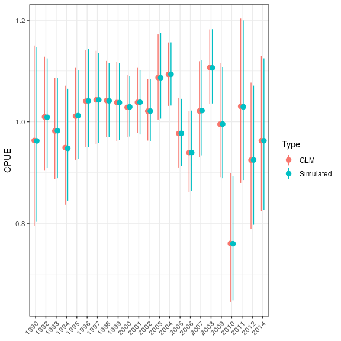

```r
cpue1 <- get_index(fit = fit2, year = "Year") %>% mutate(Type = "GLM")
cpue2 <- cpue1 %>% mutate(Type = "Simulated")
for (ii in 1:nrow(cpue1)) {
  # sdd <- cpue1$Est.Error[ii] # this is wrong
  sdd <- log(1 + cpue1$Est.Error[ii] / cpue1$Estimate[ii])
  r1 <- rlnorm(n = 5000, log(cpue1$Q50[ii]), sdd)
  cpue2$Q50[ii] <- median(r1)
  cpue2$Qlower[ii] <- quantile(r1, probs = 0.025)
  cpue2$Qupper[ii] <- quantile(r1, probs = 0.975)
}

ggplot(data = rbind(cpue1, cpue2), aes(x = Year, y = Q50, colour = Type)) +
  geom_pointrange(aes(ymin = Qlower, ymax = Qupper), position = position_dodge(width = 0.5)) +
  labs(x = NULL, y = "CPUE") +
  theme_bw() +
  theme(axis.text.x = element_text(angle = 45, hjust = 1))
```